# Data 200: Week 7 EDA Solutions

# Wrangling the data

## Preparing the usda data

```r
usa_food_og <- read_csv("StateandCountyData.csv", na = c("-8888", "-9999"))

usa_food <- usa_food_og |>
  clean_names() |>
  pivot_wider(
    id_cols = c(fips, state, county),
    names_from = variable_code,
    values_from = value
  ) |>
  clean_names()
```

## Preparing the map data

# Analyzing the data

## Exploring associations

```
# A tibble: 2 × 3
  metro23 `median(povrate21)` `median(pct_laccess_pop19)`
  <lgl>                 <dbl>                       <dbl>
1 FALSE                  15.5                        27.8
2 TRUE                   12.3                        16.6
```

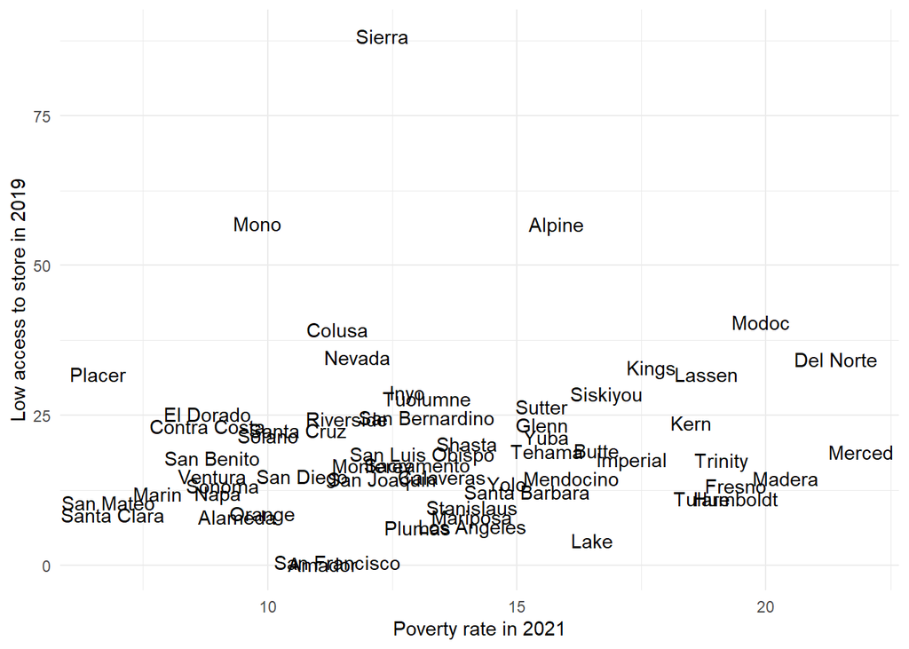

## Table of all variables you investigated by county

| county | pct_laccess_pop19 | povrate21 | metro23 |
| --- | --- | --- | --- |
| Alameda | 8.0836754 | 9.4 | TRUE |
| Alpine | 56.9692421 | 15.8 | FALSE |
| Amador | 0.1741870 | 11.1 | FALSE |
| Butte | 19.1134338 | 16.6 | TRUE |
| Calaveras | 14.7361174 | 13.5 | FALSE |
| Colusa | 39.3297462 | 11.4 | FALSE |
| Contra Costa | 23.2283115 | 8.8 | TRUE |
| Del Norte | 34.4071922 | 21.4 | FALSE |
| El Dorado | 25.2228908 | 8.8 | TRUE |
| Fresno | 13.3270693 | 19.4 | TRUE |
| Glenn | 23.4450111 | 15.5 | FALSE |
| Humboldt | 11.1862726 | 19.4 | FALSE |
| Imperial | 17.6411171 | 17.3 | TRUE |
| Inyo | 28.8879032 | 12.8 | FALSE |
| Kern | 23.7723370 | 18.5 | TRUE |
| Kings | 33.0286903 | 17.7 | TRUE |
| Lake | 4.1775646 | 16.5 | FALSE |
| Lassen | 31.8917122 | 18.8 | FALSE |
| Los Angeles | 6.5318885 | 14.1 | TRUE |
| Madera | 14.4942818 | 20.4 | TRUE |
| Marin | 11.8875475 | 7.8 | TRUE |
| Mariposa | 8.0738029 | 14.1 | FALSE |
| Mendocino | 14.4812298 | 16.1 | FALSE |
| Merced | 18.9374237 | 21.9 | TRUE |
| Modoc | 40.5433197 | 19.9 | FALSE |
| Mono | 57.0939026 | 9.8 | FALSE |
| Monterey | 16.6298370 | 12.1 | TRUE |
| Napa | 12.0841713 | 9.0 | TRUE |
| Nevada | 34.7623787 | 11.8 | FALSE |
| Orange | 8.6717873 | 9.9 | TRUE |
| Placer | 31.9290962 | 6.6 | TRUE |
| Plumas | 6.2981706 | 13.0 | FALSE |
| Riverside | 24.4813786 | 11.6 | TRUE |
| Sacramento | 16.8135395 | 13.0 | TRUE |
| San Benito | 17.8734379 | 8.9 | TRUE |
| San Bernardino | 24.6561451 | 13.2 | TRUE |
| San Diego | 14.9272852 | 10.7 | TRUE |
| San Francisco | 0.5845079 | 11.4 | TRUE |
| San Joaquin | 14.4129105 | 12.3 | TRUE |
| San Luis Obispo | 18.6220913 | 13.1 | TRUE |
| San Mateo | 10.5172138 | 6.8 | TRUE |
| Santa Barbara | 12.2439404 | 15.2 | TRUE |
| Santa Clara | 8.4875870 | 6.9 | TRUE |
| Santa Cruz | 22.5828533 | 10.6 | TRUE |
| Shasta | 20.2610359 | 14.0 | TRUE |
| Sierra | 88.2499008 | 12.3 | FALSE |
| Siskiyou | 28.6446056 | 16.8 | FALSE |
| Solano | 21.6585216 | 10.0 | TRUE |
| Sonoma | 13.2963934 | 9.1 | TRUE |
| Stanislaus | 9.6709414 | 14.1 | TRUE |
| Sutter | 26.4829903 | 15.5 | TRUE |
| Tehama | 19.0901756 | 15.6 | FALSE |
| Trinity | 17.6034508 | 19.1 | FALSE |
| Tulare | 11.1756515 | 18.7 | TRUE |
| Tuolumne | 27.8339367 | 13.2 | FALSE |
| Ventura | 14.8923502 | 8.9 | TRUE |
| Yolo | 13.6804819 | 14.8 | TRUE |
| Yuba | 21.4632606 | 15.6 | TRUE |

## Creating the map

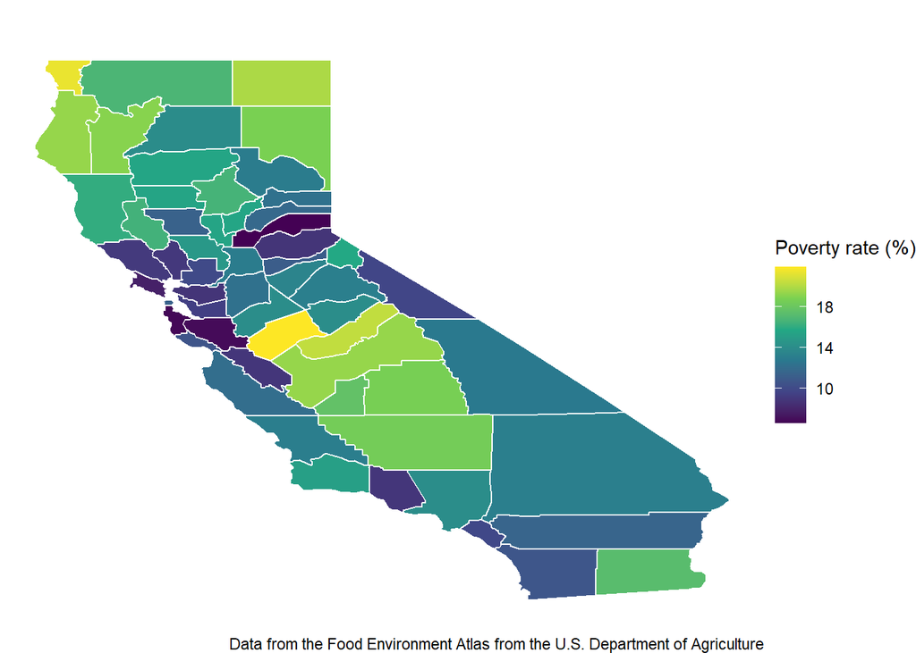

# Reflection questions

## Q1

Recall I provided you with the code for reading in, pivoting the data, and renaming the data. I did not drop any data in those steps. Please examine the `usa_food_og` and `usa_food` datasets and explain key differences

### Response

## Q2

Which county had the lowest poverty rate in 2021 and which county had the highest?

### Response

## Q3

Identify one county that seemed unusual for the variables you looked at. Describe what you think is unusual about it.

### Response

## Q4

Your chosen variable: What additional variable did you investigate, and why did you think it might be related to poverty? Explain what the variable measures, including its units and year. Describe what you found and whether it matched your expectations.

### Response

## Q5

Geographic patterns: Describe a geographic pattern in poverty rates visible in your map, referring to specific counties or regions of your state. What does the map help you notice that is harder to see in the table or scatterplot?

### Response

## Q6: Homework Help

Have you done the homework by yourself, with a peer(s), or used tools like ChatGPT?

- If you provided help to a peer(s) and/or got help from your peers(s) please explain briefly what this entailed.
- If you used AI tools like ChatGPT, include the prompts you used and explain how the tool helped supported your learning.

### Response